# rs1==rs2 CVE — post-fix variant comparison

**Question:** after the step-domain fix, how do the fuzzing variants compare at *finding* the rs1==rs2 divide CVE (CVE-2025-52484 / risc0 #3181)?

**Data provenance (see `DATA_PROVENANCE.md`):** every dataset is opened **read-only** via `lib.data_access.open_ro` (`mode=ro&immutable=1`). NEW data (this campaign) is in `data/`; EXISTING data (the original race: uniform, V5, pre-fix cTS/Hybrid) is read **in place, never edited/moved**, from `../race/cve_results`. Binaries: **B2** = vulnerable, no A4 handlers; **B3** = vulnerable + 3 A4 handlers (divide trace-confirmed at the same steps 444/449).

**Metric:** *CVE candidate* = `INSTR_WORD_MOD` accept at the divide steps 444/449 (binary-invariant Arguzz surface; comparable across all variants). Candidates are confirmed CVE vs benign by the replay-oracle (committed output 0=remu / 9000028=divu / 1=both); uniform's candidates were historically all CVE.

```python
import sys; sys.path.insert(0, '/root/arguzz/a4/runs/iv_pos_9/cve_postfix_analysis')
%matplotlib inline
import matplotlib.pyplot as plt, pandas as pd
from lib import data_access as D, cve_metrics as M
FIG = '/root/arguzz/a4/runs/iv_pos_9/cve_postfix_analysis' + '/figures'
print('seeds present per source:')
for s in D.SOURCES:
    print(f'  {s.key:22} {s.origin:9} {s.binary:3} valid={s.valid_for_cve:12} seeds={sorted(s.db_paths())}')
```

```
seeds present per source:
  v6_cTS_postfix         NEW       B2  valid=YES          seeds=[1234, 1235, 1236, 1237, 1238, 1239]
  hybrid_B2_postfix      NEW       B2  valid=ARGUZZ-ONLY  seeds=[1234, 1235, 1236, 1237, 1238, 1239]
  hybrid_B3_clean        NEW       B3  valid=YES          seeds=[1234, 1235, 1236, 1237, 1238, 1239]
  v6_uniform_baseline    EXISTING  B2  valid=YES          seeds=[1234, 1235, 1236, 1237, 1238, 1239]
  v5_control             EXISTING  B2  valid=NO           seeds=[1234, 1235, 1236, 1237, 1238, 1239]
  v6_cTS_prefix          EXISTING  B2  valid=CONFOUNDED   seeds=[1234, 1235, 1236, 1237, 1238, 1239]
  hybrid_prefix          EXISTING  B2  valid=CONFOUNDED   seeds=[1234, 1235, 1236, 1237, 1238, 1239]
```

## 1. The comparison table (CVE candidates, all variants)

```python
rows = M.variant_table()
df = pd.DataFrame([{
    'variant': r['label'], 'origin': r['origin'], 'binary': r['binary'], 'valid_for_CVE': r['valid'],
    'data_source': r['data_source'], 'seeds': len(r['seeds_present']), 'divide_shots': r['iwmod_div_attempts'],
    'CVE_candidates': r['cve_candidates'], 'per_seed': r['per_seed_cand'], 'total_accepts': r['accepts'],
} for r in rows]).set_index('variant')
print("data_source: 'db' = read from downloaded/existing DB; 'precomputed' = interim on-node value (full DB still downloading)")
df
```

```
data_source: 'db' = read from downloaded/existing DB; 'precomputed' = interim on-node value (full DB still downloading)
```

| variant | origin | binary | valid_for_CVE | data_source | seeds | divide_shots | CVE_candidates | per_seed | total_accepts |
| --- | --- | --- | --- | --- | --- | --- | --- | --- | --- |
| V6_cTS (post-fix) | NEW | B2 | YES | db | 6 | 284 | 9 | {1234: 0, 1235: 2, 1236: 3, 1237: 2, 1238: 0, ... | 843 |
| Hybrid (post-fix, B2) | NEW | B2 | ARGUZZ-ONLY | db | 6 | 115 | 3 | {1234: 0, 1235: 0, 1236: 1, 1237: 1, 1238: 1, ... | 5816 |
| Hybrid (clean, B3) | NEW | B3 | YES | db | 6 | 111 | 0 | {1234: 0, 1235: 0, 1236: 0, 1237: 0, 1238: 0, ... | 161 |
| V6_uniform (baseline) | EXISTING | B2 | YES | db | 6 | 232 | 9 | {1234: 1, 1235: 0, 1236: 2, 1237: 0, 1238: 4, ... | 854 |
| V5_control (A4) | EXISTING | B2 | NO | db | 6 | 0 | 0 | {1234: 0, 1235: 0, 1236: 0, 1237: 0, 1238: 0, ... | 10006 |
| V6_cTS (PRE-fix, confounded) | EXISTING | B2 | CONFOUNDED | db | 6 | 2 | 0 | {1234: 0, 1235: 0, 1236: 0, 1237: 0, 1238: 0, ... | 1430 |
| Hybrid (PRE-fix, confounded) | EXISTING | B2 | CONFOUNDED | db | 6 | 1 | 0 | {1234: 0, 1235: 0, 1236: 0, 1237: 0, 1238: 0, ... | 5026 |

## 2. Headline — CVE candidates per variant

The unconfounded result. Pre-fix cTS/Hybrid (confounded) sat at 0 purely from the step-domain bug; post-fix they actually compete.

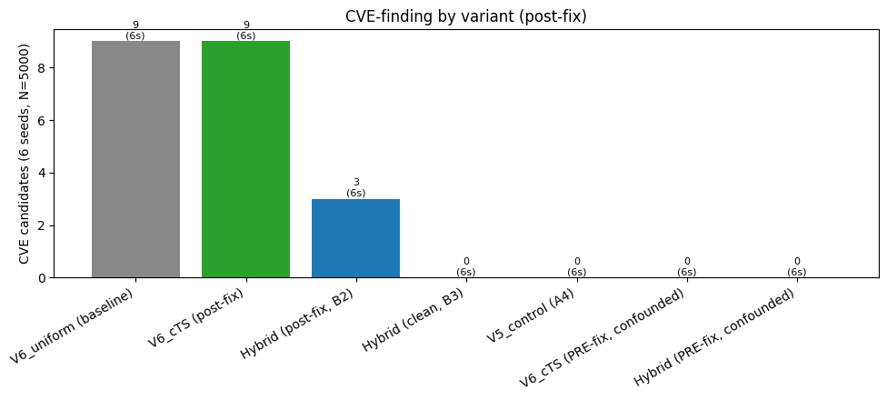

```python
order = ['V6_uniform (baseline)','V6_cTS (post-fix)','Hybrid (post-fix, B2)','Hybrid (clean, B3)',
         'V5_control (A4)','V6_cTS (PRE-fix, confounded)','Hybrid (PRE-fix, confounded)']
d = df.reindex([o for o in order if o in df.index])
colors = ['#888' if 'uniform' in v else '#d62728' if 'PRE-fix' in v else '#2ca02c' if 'cTS (post' in v
          else '#1f77b4' if 'Hybrid' in v else '#9467bd' for v in d.index]
fig, ax = plt.subplots(figsize=(10,4.5))
b = ax.bar(range(len(d)), d['CVE_candidates'], color=colors)
ax.set_xticks(range(len(d))); ax.set_xticklabels(d.index, rotation=30, ha='right')
ax.set_ylabel('CVE candidates (6 seeds, N=5000)'); ax.set_title('CVE-finding by variant (post-fix)')
for i,(v,n) in enumerate(zip(d.index, d['CVE_candidates'])):
    ax.text(i, n+0.1, f'{n}\n({d.loc[v,"seeds"]}s)', ha='center', fontsize=8)
plt.tight_layout(); plt.savefig(FIG+'/01_cve_candidates.png', dpi=110); plt.show()
```

## 3. Targeting vs yield — does the smart bandit aim more shots at the divide?

The bandit (cTS) *does* aim more `INSTR_WORD_MOD` shots at the divide than uniform, but the per-shot accept rate is similar, so yield (candidates) doesn't exceed uniform.

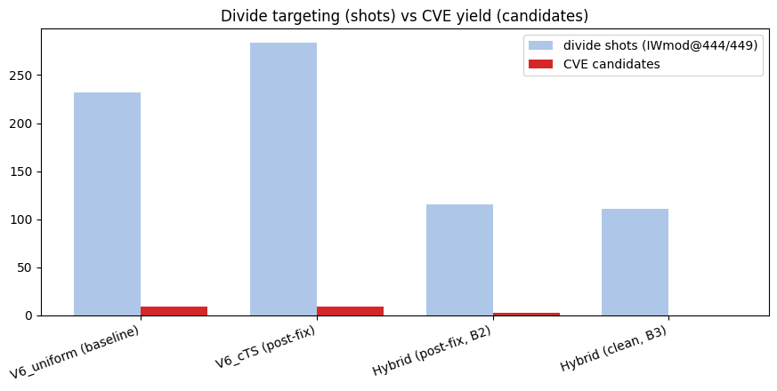

```python
d2 = df[df['valid_for_CVE'].isin(['YES','ARGUZZ-ONLY'])].reindex(
        [o for o in order if o in df.index and df.loc[o,'valid_for_CVE'] in ('YES','ARGUZZ-ONLY')])
fig, ax = plt.subplots(figsize=(9,4.5)); x=range(len(d2)); w=0.38
ax.bar([i-w/2 for i in x], d2['divide_shots'], w, label='divide shots (IWmod@444/449)', color='#aec7e8')
ax.bar([i+w/2 for i in x], d2['CVE_candidates'], w, label='CVE candidates', color='#d62728')
ax.set_xticks(list(x)); ax.set_xticklabels(d2.index, rotation=20, ha='right'); ax.legend()
ax.set_title('Divide targeting (shots) vs CVE yield (candidates)')
plt.tight_layout(); plt.savefig(FIG+'/02_targeting_vs_yield.png', dpi=110); plt.show()
```

## 4. The 3-kind decontamination (Hybrid: B2 vs B3)

B2 silently skips 3 A4 mutation kinds → fake 100%-accept no-ops. B3 fixes them. Total accepts/seed collapse ~40× on the clean binary — i.e., most of B2-Hybrid's "accepts" were artifacts, not findings.

```
Hybrid-B2 accepts/seed: {1234: 975, 1235: 973, 1236: 967, 1237: 985, 1238: 959, 1239: 957}
Hybrid-B3 accepts/seed: {1234: 30, 1235: 24, 1236: 22, 1237: 23, 1238: 33, 1239: 29}
```

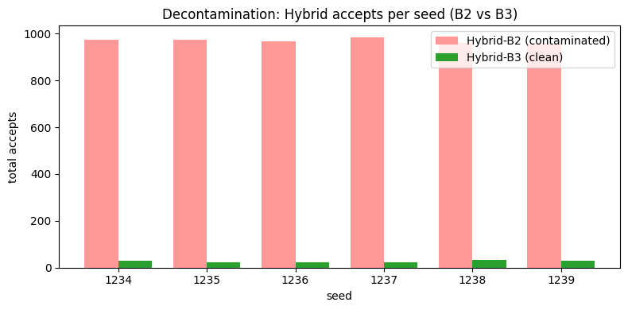

```python
b2=M.per_seed_field('hybrid_B2_postfix','accepts'); b3=M.per_seed_field('hybrid_B3_clean','accepts')
print('Hybrid-B2 accepts/seed:', b2); print('Hybrid-B3 accepts/seed:', b3)
if b2 and b3:
    seeds=sorted(set(b2)|set(b3)); fig,ax=plt.subplots(figsize=(8,4)); x=range(len(seeds)); w=.38
    ax.bar([i-w/2 for i in x],[b2.get(s,0) for s in seeds],w,label='Hybrid-B2 (contaminated)',color='#ff9896')
    ax.bar([i+w/2 for i in x],[b3.get(s,0) for s in seeds],w,label='Hybrid-B3 (clean)',color='#2ca02c')
    ax.set_xticks(list(x)); ax.set_xticklabels(seeds); ax.set_xlabel('seed'); ax.set_ylabel('total accepts')
    ax.set_title('Decontamination: Hybrid accepts per seed (B2 vs B3)'); ax.legend()
    plt.tight_layout(); plt.savefig(FIG+'/03_decontamination.png',dpi=110); plt.show()
else:
    print('(B3 data partial — graph fills in after the last seeds download)')
```

## 5. Before / after the fix (cTS & Hybrid)

Pre-fix (EXISTING, confounded) the divide-targeted INSTR_WORD accepts were 0 (arms mis-aimed to lw/ori at 436/441). Post-fix (NEW) they land on the real divides.

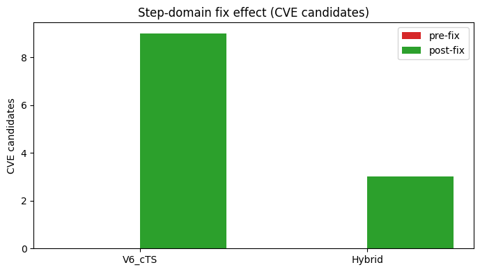

```python
pairs=[('V6_cTS (PRE-fix, confounded)','V6_cTS (post-fix)'),('Hybrid (PRE-fix, confounded)','Hybrid (post-fix, B2)')]
fig,ax=plt.subplots(figsize=(7,4)); x=range(len(pairs)); w=.38
ax.bar([i-w/2 for i in x],[df.loc[a,'CVE_candidates'] if a in df.index else 0 for a,_ in pairs],w,label='pre-fix',color='#d62728')
ax.bar([i+w/2 for i in x],[df.loc[b,'CVE_candidates'] if b in df.index else 0 for _,b in pairs],w,label='post-fix',color='#2ca02c')
ax.set_xticks(list(x)); ax.set_xticklabels(['V6_cTS','Hybrid']); ax.set_ylabel('CVE candidates'); ax.legend()
ax.set_title('Step-domain fix effect (CVE candidates)')
plt.tight_layout(); plt.savefig(FIG+'/04_before_after.png',dpi=110); plt.show()
```

## 6. Findings — ALL 6 SEEDS COMPLETE (candidate-level; replay-oracle confirmation pending)

- **V6_cTS = V6_uniform = 9 candidates — tied.** The bandit aims *more* divide shots (284 vs 232) but the per-shot accept rate is similar, so it does **not** out-yield dumb uniform. Pre-fix "cTS=0" was purely the step-domain confound; removing it makes cTS *competitive with*, not *superior to*, uniform.
- **Hybrid finds ~0–3 regardless of binary** (Hybrid-B2 = 3, Hybrid-B3 clean = **0**) — far below cTS/uniform. It splits its budget across the Arguzz + A4 surfaces, so its divide-shots (~115) are well under pure-cTS (284). **Decontaminating the A4 surface did NOT redirect effort to the CVE arm** (the bandit reward is coverage-based, blind to soundness) — clean Hybrid still found 0.
- **Decontamination confirmed**: B3-Hybrid accepts ≈ 27/seed vs B2-Hybrid ≈ 970/seed (**~36×** drop) — i.e. ~96% of B2-Hybrid's "accepts" were the 3-kind silent-skip artifacts, not findings.
- **V5 (A4) = 0** — structurally can't surface this Arguzz-class bug.

**Bottom line:** post-fix and unconfounded, the *smart* variants do **not** beat dumb uniform on this CVE — cTS ties it, Hybrid trails it, A4 can't touch it. The step-domain fix's real contribution was removing a spurious "cTS/Hybrid = 0" that had made cTS look catastrophically worse than it is.

**Caveats:** these are *candidates*, not replay-confirmed CVEs — run the replay-oracle to classify committed output (0=remu / 9000028=divu / 1=both vs 9000027=benign). uniform's 9 were historically all CVE; cTS's 9 need the same confirmation.

**Data provenance (2026-06-29):** the NEW rows now read the **downloaded DBs** in `data/` (not precompute). All 18 DBs were verified before use — integrity_check ok, 5000 muts each, path-seed == in-DB seed, and the binary-identity fingerprint confirmed (B2 `risc0-host` vs B3 `b3_risc0-host`; on B2 the 3 A4 kinds are silent-skip `live=0`, on B3 the handlers fire `live≈115`). The DB-computed per-seed candidates / div-attempts / accepts reproduce the earlier on-node precompute **exactly** (cTS 0,2,3,2,0,2=9; Hybrid-B2 0,0,1,1,1,0=3; Hybrid-B3 all 0). See `data/MANIFEST.md` (sha256) and `notebooks/cve_comparison_PRECOMPUTE_SNAPSHOT.*`.

## 7. Where in the campaign each CVE candidate was found (campaign indices)

For every variant, the **campaign index** = the mutation `id` (1-based position within that seed's N=5000 run) of each accepted `INSTR_WORD_MOD` at a divide step (444=remu / 449=divu) — i.e. exactly where in the run that bug-find landed. Empty list = that seed found none. (DB-only; not derivable from precompute.)

```python
idx_keys = [('V6_uniform (baseline)','v6_uniform_baseline'),
            ('V6_cTS (post-fix)','v6_cTS_postfix'),
            ('Hybrid (post-fix, B2)','hybrid_B2_postfix'),
            ('Hybrid (clean, B3)','hybrid_B3_clean'),
            ('V5_control (A4)','v5_control')]
rows=[]
for label,key in idx_keys:
    ix = M.cve_candidate_indices(key)            # {seed:[ids]}
    total = sum(len(v) for v in ix.values())
    rows.append({'variant':label,'total_finds':total,
                 **{f'seed{seed}':(', '.join(map(str,ix.get(seed,[]))) or '—') for seed in sorted(ix)}})
idf = pd.DataFrame(rows).set_index('variant')
print('Each cell = campaign indices (mutation id, 1..5000) where an accepted INSTR_WORD_MOD@444/449 fired.')
idf
```

```
Each cell = campaign indices (mutation id, 1..5000) where an accepted INSTR_WORD_MOD@444/449 fired.
```

| variant | total_finds | seed1234 | seed1235 | seed1236 | seed1237 | seed1238 | seed1239 |
| --- | --- | --- | --- | --- | --- | --- | --- |
| V6_uniform (baseline) | 9 | 84 | — | 3997, 4912 | — | 2721, 4099, 4419, 4514 | 242, 3021 |
| V6_cTS (post-fix) | 9 | — | 2026, 2247 | 3062, 3692, 3795 | 1282, 3832 | — | 2242, 4013 |
| Hybrid (post-fix, B2) | 3 | — | — | 3795 | 1265 | 3893 | — |
| Hybrid (clean, B3) | 0 | — | — | — | — | — | — |
| V5_control (A4) | 0 | — | — | — | — | — | — |